# Estatística Computacional I

Trabalho 02 - (21/05/2020)

Eduardo Freire Mangabeira

Orientações:

1. Responda as questões deixando o código R nos respectivos chunks
2. Mantenha os nomes de objetos solicitados na questão
3. Sempre deixe por último o objeto que responde a pergunta
4. Salve o arquivo com o seu nome
5. Execute o Preview para gerar o html
6. Envie o html e Rmd pelo CR 7 . link do arquivo: [https://bit.ly/2WRHoXB]

## 1- Leia o arquivo forbes2000.csv carregando-o em um objeto com nome df.

```r
df = read.csv("forbes2000.csv", sep=';')
```

A lista Forbes 2000 é um ranking das maiores empresas do mundo, medido por vendas, lucros, ativos e valor de mercado.

## 2- Renomeie as colunas com os nomes a seguir, que já estão na ordem das colunas como segue: rank, empresa, pais, categoria, vendas, lucro, ativo, valor).Mantenha o nome df.

```r
names(df)
```

```
[1] "rank"        "name"        "country"     "category"    "sales"
[6] "profits"     "assets"      "marketvalue"
```

```r
nome <- c('rank', 'empresa', 'pais', 'categoria', 'vendas', 'lucro', 'ativo', 'valor')
colnames(df) <- nome
nome
```

```
[1] "rank"      "empresa"   "pais"      "categoria" "vendas"    "lucro"
[7] "ativo"     "valor"
```

## 3- Quantos e quais países estão nesta lista?

```r
n_paises= NROW(df$pais)
n_paises
```

```
[1] 2000
```

```r
paises= df$pais
unique(paises)
```

```
 [1] "United States"                "United Kingdom"
 [3] "Japan"                        "Switzerland"
 [5] "Netherlands"                  "Netherlands/ United Kingdom"
 [7] "France"                       "Germany"
 [9] "Italy"                        "Spain"
[11] "South Korea"                  "China"
[13] "Bermuda"                      "Canada"
[15] "Finland"                      "Australia"
[17] "Russia"                       "Belgium"
[19] "Kong/China"                   "Norway"
[21] "Australia/ United Kingdom"    "Brazil"
[23] "Denmark"                      "Sweden"
[25] "Hong Kong/China"              "United Kingdom/ Australia"
[27] "Ireland"                      "India"
[29] "Panama/ United Kingdom"       "Taiwan"
```

[output cut: 16 more lines]

## 4- Qual são os 10 paises que aparecem com mais frequencia? Faça uma tabela com o nome do país e a frequencia.

```r
paises_10_mais <- sort(table(df$pais),decreasing=TRUE)[1:10]
paises_10_mais
```

```
 United States          Japan United Kingdom        Germany         France
           751            316            137             65             63
        Canada    South Korea          Italy      Australia         Taiwan
            56             45             41             37             35
```

## 5- Quantas e quais são as empresas brasileiras? A lista de empresas deve estar em ordem alfabética

```r
nrow(df[df$pais=='Brazil', ])
```

```
[1] 15
```

```r
brasil <- df[df$pais=='Brazil', ]
brasil <- brasil[order(brasil$empresa), ]
head(brasil)
```

|  | rank | empresa | pais | categoria | vendas | lucro | ativo | valor |
| --- | --- | --- | --- | --- | --- | --- | --- | --- |
| 1061 | 1061 | AmBev | Brazil | Food drink & tobacco | 2,07 | 0,43 | 3,06 | 9,57 |
| 1562 | 1562 | Aracruz Celulose | Brazil | Materials | 1,06 | 0,3 | 2,77 | 2,87 |
| 247 | 247 | Banco Bradesco Group | Brazil | Banking | 15,76 | 0,8 | 60,89 | 6,83 |
| 321 | 321 | Banco do Brasil | Brazil | Banking | 12,09 | 0,57 | 57,8 | 5,77 |
| 1915 | 1915 | Brasil Telecom | Brazil | Telecommunications services | 2 | 0,12 | 4,22 | 2,45 |
| 1913 | 1913 | CBD-Brasil Distribuieco | Brazil | Trading companies | 3,74 | 0,08 | 2,99 | 2,64 |

```r
NA
NA
```

## 6- Compare os valor médio das empresas brasileiras com as demais empresas. Calcule a média e variância. O resultado deve ser uma tabela com as colunas País,Média_Vendas e Média_Vendas.

```r
valores_br = as.numeric(gsub(",",".", brasil$valor))

valores_wr = df[df$pais != 'Brazil',]
valores_wr = as.numeric(gsub(",",".", df$valor))

comparacao <- matrix(c("Brasil","Resto do Mundo", mean(valores_br),mean(valores_wr), var(valores_br), var(valores_wr)),ncol=3,byrow=F)

colnames(comparacao) <- c("País","Média_Valores","Variancia_Valores")
tabela <- as.table(comparacao)
tabela
```

```
  País           Média_Valores Variancia_Valores
A Brasil         7.718         81.5038742857143
B Resto do Mundo 11.877655     598.301217459705
```

## 7- Utilize o boxplot para a comparação da questão 06

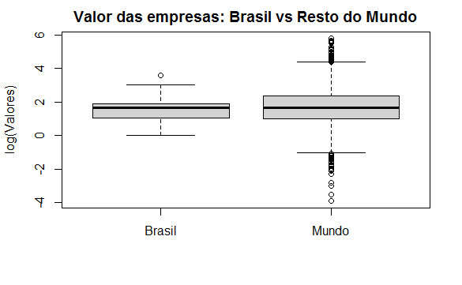

```r
# usei log para ficar numa escala melhor
boxplot(log(valores_br), log(valores_wr), ylab="log(Valores)", main = "Valor das empresas: Brasil vs Resto do Mundo", names = c("Brasil", "Mundo"))
```